# Práctica 2 de PLN: web scraping

En esta práctica vamos a realizar distintos ejercicios sobre captura de contenidos web (web scraping) usando las librerñias `request` y `BeautifulSoup`.

### Nombres:

Introduce en esta celda los nombres de los dos integrantes del grupo:\ Yana Veitsman

```python
import requests
from bs4 import BeautifulSoup
```

## Parte 1: captura de una noticia

En este parte vamos a descargarnos una noticia de una página web y guardar su contenido en disco.

```python
url = "https://elpais.com/sociedad/2019/11/13/actualidad/1573632952_315974.html"
try:
    page = requests.get(url)
except:
    print("Error al abrir la URL")
```

```python
# parseamos el html usando BeautifulSoup y lo guardamos en la variable `soup`
soup = BeautifulSoup(page.text, 'html.parser')
```

El contenido del artículo (texto del cuerpo) se encuentra dentro de un `<div>` de la página con el id `cuerpo_noticia` (puedes inspeccionar la estructura HTML de la página en el navegador para comprobarlo)

```python
# Buscamos el <div> correspondiente y sacamos su contenido:
content = soup.find('div', id="cuerpo_noticia")

article = []
for i in content.find_all('p'):
    article.append(i.text)

print('\n'.join(article))
```

```
Los venecianos viven en esta época del año refrescando cada minuto la aplicación del Centro de Previsión de Mareas, que permite saber hasta qué nivel puede llegar el acqua alta. El martes había luna llena y muchos se temieron lo peor, pero se fueron a cenar con el último dato de 140 centímetros. Pas…
La ciudad empieza a estar harta de algo que todo el mundo cree que se podría evitar. Los efectos del cambio climático, que han aumentado la frecuencia y la intensidad de las tradicionales mareas de otoño (el año pasado sucedió algo parecido), un fuerte temporal y la negligencia en la construcción de…
Los vecinos ya no creen en las promesas políticas. Marco Gazzetta achicaba agua en su negocio de máscaras junto a la plaza Rialto. Cuando fue a abrir por la mañana sabía que encontraría todo el género flotando. “La app nos dio otro resultado. Nos fuimos a casa pensando que no superaría los 140 centí…
Javier Jordà, científico del Instituto Español de Oceanografía en Baleares y autor de una investigación que muestra cómo la subida del nivel del mar haría aumentar la frecuencia de inundaciones en Venecia a final de siglo, coincide y vincula lo que está ocurriendo al calentamiento: “Lo que antes pas…
El nivel del mar en noviembre
en Venecia
Mediciones en la Punta della Salute en metros
Tamaño
comparativo
1,80 m
2,0
22.50
1,87 m
1,5
1,0
0,5
0,0
Día 1
5
10
13
Previsiones para los próximos días
Tamaño
comparativo
1,80 m
2,0
1,5
1,0
0,5
0,0
13
14
15
16
17 nov.
Fuente: Comune di Venezia.
Y. Clemente / EL PAÍS
El nivel del mar en noviembre en Venecia
Mediciones en la Punta della Salute
Tamaño
```

[output cut: 62 more lines]

```
Esther Sánchez
Gabriel Jordà (Salamanca, septiembre 1975) publicó hace siete años un estudio junto con otros dos científicos en el que se mostraba que una subida moderada del nivel del mar haría aumentar la frecuencia de inundaciones en la ciudad de Venecia a final de siglo.

P. ¿Cómo influye el cambio climático en el acqua alta?
R. Si este episodio de acqua alta, que no ha sido de los más fuertes, se hubiera producido en los años cincuenta habría sido moderado sin llegar a las cifras que ha alcanzado. Las mareas continúan siendo las mismas, pero la subida del nivel del mar ha multiplicado sus consecuencias. Todo ello sumado…
P. ¿Qué le espera a la ciudad?
R. </CF>Si se estudian las mareas que superan los 140 centímetros, las excepcionales, su pico máximo que ahora puede durar 10 minutos podría llegar a prolongarse durante un mes al año. Y una inundación de 90 centímetros, que se califica de molesta, podría pasar de los dos o tres días al año actuales…
P. ¿Cuánto ha crecido el Mediterráneo?
R. Tomando como referencia los inicios del siglo XX, ha subido entre 20 y 25 centímetros. Detrás de su crecida se encuentra el aumento de la temperatura del Mediterráneo y del Atlántico, además del deshielo. Todo ello provoca su expansión.
P. ¿Desaparecerá Venecia?
R. La humanidad es muy resiliente y quizá se encuentren sistemas para salvarla, pero estará inundada durante más tiempo. En el peor escenario puede sufrir mareas nueve meses al año y eso sería un problema enorme.
P. ¿Hay soluciones?
R. Si se cambia de política y se cumple el Acuerdo de París, Venecia pasaría de estar inundada dos terceras partes del año a una. El mar seguirá subiendo por la inercia, pero la diferencia sería brutal y beneficiaria a la ciudad.
P. ¿Ocurre algo similar en España?
R. El mar sube igual, pero al no existir mareas de ese tipo no hay eventos tan espectaculares. Aquí se nota en las tormentas con olas grandes, de cuatro o cinco metros, que son más devastadoras, porque aunque el oleaje sea del mismo tamaño, los diques se quedan pequeños al estar el mar más alto y lo…
```

Aquí se han colado algunos párrafos que no pertenecen al cuerpo de la noticio, sino que están en secciones interiores. Lo podemos evitar usando el parámetro `recursive=False`.  
Además el último párrafo no forma parte del cuerpo de la memoria, lo podemos filtrar con `class_=False` porque tiene un atributo de clase específico

```python
#optimizando el código
content = soup.find('div', id="cuerpo_noticia").find_all('p', class_=False, recursive=False)

article = ('\n').join([i.text for i in content])

print(article)
```

```
Los venecianos viven en esta época del año refrescando cada minuto la aplicación del Centro de Previsión de Mareas, que permite saber hasta qué nivel puede llegar el acqua alta. El martes había luna llena y muchos se temieron lo peor, pero se fueron a cenar con el último dato de 140 centímetros. Pas…
La ciudad empieza a estar harta de algo que todo el mundo cree que se podría evitar. Los efectos del cambio climático, que han aumentado la frecuencia y la intensidad de las tradicionales mareas de otoño (el año pasado sucedió algo parecido), un fuerte temporal y la negligencia en la construcción de…
Los vecinos ya no creen en las promesas políticas. Marco Gazzetta achicaba agua en su negocio de máscaras junto a la plaza Rialto. Cuando fue a abrir por la mañana sabía que encontraría todo el género flotando. “La app nos dio otro resultado. Nos fuimos a casa pensando que no superaría los 140 centí…
Javier Jordà, científico del Instituto Español de Oceanografía en Baleares y autor de una investigación que muestra cómo la subida del nivel del mar haría aumentar la frecuencia de inundaciones en Venecia a final de siglo, coincide y vincula lo que está ocurriendo al calentamiento: “Lo que antes pas…
Los daños en viviendas y comercios fueron enormes. “Centenares de miles de euros”, denunció el alcalde de la ciudad, Luigi Brugnaro, que pidió declarar el estado de emergencia. Pero la peor parte, como sucedió ya el año pasado, se la llevó la basílica de San Pedro, que se encuentra en la parte más b…
El ingeniero jefe de la basílica, Pierpaolo Campostrini, fue aún más directo. “Es una indecencia. El martes por la mañana, cuando la marea era de 140 centímetros se debió probar el Mose (acrónimo de Módulo Experimental Electromecánico). Se habría evitado el desastre en la basílica. La marea ha demos…
Los responsables de la basílica están valorando pedir la construcción de una suerte de barrera que pueda frenar el agua en caso de inundaciones en la plaza de San Marcos, revela Capostrini. Un atajo, en suma, para resolver la parálisis en la que lleva sumida la finalización del sistema de contención…
```

Si quisiéramos hacer un filtrado más específico de párrafos o contenidos, podemos definir una función lógica que devuelva a `find_all` los elementos a considerar:

```
def has_class_but_no_id(tag):
    return tag.has_attr('class') and not tag.has_attr('id')
```

Que luego usamos con:

```
content.findAll(has_class_but_no_id)
```

```python
#Por ejemplo los párrafos que contienen la palabra basílica
def contiene_basilica(tag):
    return tag.name=='p' and 'basílica' in tag.text

content = soup.find('div', {"id": "cuerpo_noticia"})
content.find_all(contiene_basilica)
```

```
[<p>Los venecianos viven en esta época del año refrescando cada minuto la aplicación del Centro de Previsión de Mareas, que permite saber hasta qué nivel puede llegar el <em>acqua alta</em>. El martes había luna llena y muchos se temieron lo peor, pero se fueron a cenar con el último dato de 140 cen…
 <p>Los daños en viviendas y comercios fueron enormes. “Centenares de miles de euros”, denunció el alcalde de la ciudad, Luigi Brugnaro, que pidió declarar el estado de emergencia. Pero la peor parte, como sucedió ya el año pasado, se la llevó la basílica de San Pedro, que se encuentra en la parte m…
 <p>El ingeniero jefe de la basílica, Pierpaolo Campostrini, fue aún más directo. “Es una indecencia. El martes por la mañana, cuando la marea era de 140 centímetros <a href="//elpais.com/sociedad/2019/11/13/actualidad/1573656253_882619.html" target="_blank">se debió probar el Mose (acrónimo de Módu…
 <p>Los responsables de la basílica están valorando pedir la construcción de una suerte de barrera que pueda frenar el agua en caso de inundaciones en la plaza de San Marcos, revela Capostrini. Un atajo, en suma, para resolver la parálisis en la que lleva sumida la finalización del sistema de conten…
```

### Ejercicio 1

Busca los párrafos dentro de la etiqueta `<div>` con el cuerpo de la noticia que contengan un elemento de tipo enlace (`<a>`)

```python
## Solución
def enlaces_en_p(tag):
    return tag.name=='a' and tag.parent.name=='p'

content = soup.find('div', {"id": "cuerpo_noticia"})
pars_con_enlaces = []
for i in content.find_all(enlaces_en_p):
    pars_con_enlaces.append(i.parent)
pars_con_enlaces
```

```
[<p>La ciudad empieza a estar harta de algo que todo el mundo cree que se podría evitar. Los efectos del <a href="//elpais.com/tag/cambio_climatico/a" target="_blank">cambio climático</a>, que han aumentado la frecuencia y la intensidad de las tradicionales mareas de otoño (el año pasado sucedió alg…
 <p dir="ltr" lang="it">Situazione drammatica <a href="https://t.co/gS63ZK2j3Q">pic.twitter.com/gS63ZK2j3Q</a></p>,
 <p>El ingeniero jefe de la basílica, Pierpaolo Campostrini, fue aún más directo. “Es una indecencia. El martes por la mañana, cuando la marea era de 140 centímetros <a href="//elpais.com/sociedad/2019/11/13/actualidad/1573656253_882619.html" target="_blank">se debió probar el Mose (acrónimo de Módu…
```

## Parte 2: captura de datos meteorológicos

En este parte vamos a capturar datos meteorológicos de la Comunitat Valenciana desde la página de la [AVAMET (Associació valenciana de meteorologia)](https://www.avamet.org).

```python
#esta página contiene los datos meteorológicos de un día concreto
fecha = '2021-02-10'
r = requests.get("https://www.avamet.org/mx-meteoxarxa.php", params={'id':fecha})
```

```python
soup = BeautifulSoup(r.text, "html.parser")
```

Los datos de todos los municipios de la CV están en una tabla de clase `tDades`

```python
tabla = soup.find("table", class_="tDades")
```

Dentro de la tabla, los datos están en las filas (`<tr>`) que tienen un elemento`<td class='rEsta'>`. Definimos una función para filtrar etiquetas con esta clase y buscamos todos los elementos internos a la tabla:

```python
def clase_rEsta(tag):
    return tag.find(class_="rEsta")
```

```python
loc = tabla.find_all(clase_rEsta)
```

```python
len(loc)
```

```
677
```

Nos fijamos por ejemplo en el primer elemento de esta lista:

```python
print(loc[0].prettify())
```

```
<tr>
 <td class="rEsta">
  <a class="negre" href="mx-fitxa.php?id=c01m038e20">
   <img alt="" height="13" src="imatges/2017/clas/estrela-mx-.png" title="" width="13">
    Castellfort
    <span class="rEstaDmxo">
     <span class="ptda">
     </span>
     AEMET
    </span>
   </img>
  </a>
 </td>
 <td class="rValm colornT16">
  2,4
 </td>
 <td class="rValm colornT17">
  4,7
 </td>
 <td class="rValm colornT18">
  7,0
 </td>
 <td class="rVal">
 </td>
 <td class="rValm colorP">
  0,0
 </td>
 <td class="rVal">
 </td>
 <td class="rVal">
 </td>
 <td class="rVal">
  <b>
  </b>
 </td>
</tr>
```

Vemos que algunas de las celdas de esta fila tienen elementos de tipo `<span>`. Si no nos interesan los podríamos eliminar con el método `.decompose()` del Tag. Pero como el texto nos interesa insertamos un espacio para separar el contenido al extraer el texto posteriormente con `.text()`:

```python
for t in loc:
    for t in t.find_all('span', class_="rEstaDmxo"):
        t.insert_before(' ')
print(loc[0].prettify())
```

```
<tr>
 <td class="rEsta">
  <a class="negre" href="mx-fitxa.php?id=c01m038e20">
   <img alt="" height="13" src="imatges/2017/clas/estrela-mx-.png" title="" width="13">
    Castellfort
    <span class="rEstaDmxo">
     <span class="ptda">
     </span>
     AEMET
    </span>
   </img>
  </a>
 </td>
 <td class="rValm colornT16">
  2,4
 </td>
 <td class="rValm colornT17">
  4,7
 </td>
 <td class="rValm colornT18">
  7,0
 </td>
 <td class="rVal">
 </td>
 <td class="rValm colorP">
  0,0
 </td>
 <td class="rVal">
 </td>
 <td class="rVal">
 </td>
 <td class="rVal">
  <b>
  </b>
 </td>
</tr>
```

```python
#Cada celda <td> dentro de la fila es una columna de la tabla
[t.text.strip() for t in loc[0].find_all("td")]
```

```
['Castellfort AEMET', '2,4', '4,7', '7,0', '', '0,0', '', '', '']
```

```python
[t for t in loc[0].find_all("td")]
```

```
[<td class="rEsta"><a class="negre" href="mx-fitxa.php?id=c01m038e20"><img alt="" height="13" src="imatges/2017/clas/estrela-mx-.png" title="" width="13"> Castellfort <span class="rEstaDmxo"><span class="ptda"></span>AEMET</span></img></a> </td>,
 <td class="rValm colornT16">2,4 </td>,
 <td class="rValm colornT17">4,7 </td>,
 <td class="rValm colornT18">7,0 </td>,
 <td class="rVal"> </td>,
 <td class="rValm colorP">0,0 </td>,
 <td class="rVal"> </td>,
 <td class="rVal"> </td>,
 <td class="rVal"><b> </b></td>]
```

```python
#Capturamos toda la tabla
datos = [[t.text.strip() for t in l.find_all("td")] for l in loc]
```

```python
#Todas las filas tienen los mismos datos
len(datos[0])
```

```
9
```

Ahora exportamos la tabla como un DataFrame de `pandas`:

```python
import pandas as pd
```

```python
data_matrix = pd.DataFrame(datos)
```

```python
data_matrix.info()
```

```
<class 'pandas.core.frame.DataFrame'>
RangeIndex: 677 entries, 0 to 676
Data columns (total 9 columns):
 #   Column  Non-Null Count  Dtype
---  ------  --------------  -----
 0   0       677 non-null    object
 1   1       677 non-null    object
 2   2       677 non-null    object
 3   3       677 non-null    object
 4   4       677 non-null    object
 5   5       677 non-null    object
 6   6       677 non-null    object
 7   7       677 non-null    object
 8   8       677 non-null    object
dtypes: object(9)
memory usage: 47.7+ KB
```

```python
#Definimos el nombre de las columnas
data_matrix.columns = ['localidad','Temp','Tmax','Tmin','Humedad','Precip',
                      'Vel.viento','Dir.viento','Vmax_viento']
```

```python
data_matrix.head(5)
```

|  | localidad | Temp | Tmax | Tmin | Humedad | Precip | Vel.viento | Dir.viento | Vmax_viento |
| --- | --- | --- | --- | --- | --- | --- | --- | --- | --- |
| 0 | Castellfort AEMET | 2,4 | 4,7 | 7,0 |  | 0,0 |  |  |  |
| 1 | Cinctorres | 4,4 | 7,4 | 9,9 | 61 | 0,6 | 16,9 | NO | 74,0 |
| 2 | Forcall | 1,6 | 7,9 | 12,3 | 64 | 0,8 | 9,2 | NO | 51,5 |
| 3 | Morella centre | 4,4 | 7,4 | 10,6 | 64 | 1,2 | 10,6 | O | 56,3 |
| 4 | Morella Fàbrica Giner | 0,6 | 7,8 | 11,4 | 66 | 1,2 | 2,4 | O | 35,4 |

### Ejercicio 2

Crea un script para capturar los datos de un territorio y una fecha concretas a través de la URL:\ `https://www.avamet.org/mx-meteoxarxa.php?id={fecha}&territori={territorio}`\ Los códigos de cada territorio están en el elemento `select` siguiente:

```python
content = soup.find("select", attrs={'name':"freg_territori"})
```

```python
# Solución
import pandas as pd
def clase_rEsta(tag):
    return tag.find(class_="rEsta")

# cogemos todas las localidades y ponemos los códigos a un diccionario
terrs = {}
for i in content:
    if i.name == 'option' and i.has_attr('value'):
            terrs[i.text.strip()] = i['value']

fecha = '2021-02-10'
terr = terrs['l′Alcalatén'] # por ejemplo, cogemos los datos de l′Alcalatén

# hacemos un request a la página
r = requests.get("https://www.avamet.org/mx-meteoxarxa.php", params={'id':fecha, 'territori':terr})

# extraemos los datos
soup = BeautifulSoup(r.text, "html.parser")
tabla = soup.find("table", class_="tDades")
loc = tabla.find_all(clase_rEsta)

# cogemos todos los datos
datos = [[t.text.strip() for t in l.find_all("td")] for l in loc]

# convertimos los datos a un Dataframe
data_matrix = pd.DataFrame(datos)
data_matrix.columns = ['localidad','Temp','Tmax','Tmin','Humedad','Precip',
                      'Vel.viento','Dir.viento','Vmax_viento']

data_matrix # imprimimos los datos en una tabla de todas las localidades
```

|  | localidad | Temp | Tmax | Tmin | Humedad | Precip | Vel.viento | Dir.viento | Vmax_viento |
| --- | --- | --- | --- | --- | --- | --- | --- | --- | --- |
| 0 | Atzeneta del Maestrat | 3,3 | 11,9 | 16,6 | 52 | 0,8 | 6,1 | SO | 37,0 |
| 1 | Atzeneta del MaestratSant Gregori AEMET | 4,6 | 10,5 | 16,5 |  | 0,4 |  |  | 76,0 |
| 2 | l′AlcoraIES Ximén d′Urrea | 8,3 | 13,7 | 17,6 | 52 | 1,4 | 16,4 | ONO | 74,0 |
| 3 | Benafigos | 4,4 | 8,0 | 10,7 | 58 | 0,4 | 31,7 | ONO | 101,4 |
| 4 | Xodos | 3,0 | 6,2 | 8,9 | 63 | 3,4 | 29,9 | O | 91,7 |
| 5 | Xodosla Vega | -0,7 | 6,2 | 10,8 | 67 | 4,0 | 22,9 | NO | 75,6 |
| 6 | les Useres | 9,2 | 12,8 | 15,5 | 50 | 1,2 | 22,7 | ONO | 80,5 |
| 7 | Vistabella del MaestratSant Joan de Penyagolosa | -1,3 | 3,5 | 6,6 | 73 | 5,4 | 16,1 | OSO | 61,2 |
| 8 | Vistabella del Maestrat | 1,4 | 4,9 | 7,5 | 69 | 1,0 | 24,3 | ONO | 74,0 |

### ejercicio extra:

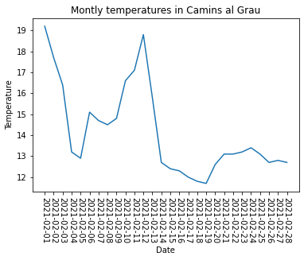

```python
import re
import pandas as pd
import matplotlib.pyplot as plt

def clase_rEsta(tag):
    return tag.find(class_="rEsta")

regexp = re.compile(r'Camins al Grau')
par_terr = terrs['València']
temps = {}

times = pd.date_range(start='2021-02-01', end='2021-02-28')

for i in times:

    fecha = i.strftime("%Y-%m-%d")

    r = requests.get("https://www.avamet.org/mx-meteoxarxa.php", params={'id':fecha, 'territori':par_terr})

    soup = BeautifulSoup(r.text, "html.parser")
    tabla = soup.find("table", class_="tDades")
    loc = tabla.find_all(clase_rEsta)
    camins_data = []

    for i in loc:
        if regexp.search(str(i)):
            camins_data.append(i)

    for i in camins_data:
        temps[fecha]= float(i.find("td", class_="rValm").find_next_sibling("td", class_="rValm").text.strip().replace(",","."))

lists = sorted(temps.items())
x,y = zip(*lists)
plt.xticks(rotation=270)
plt.title('Montly temperatures in Camins al Grau')
plt.xlabel('Date')
plt.ylabel('Temperature')
plt.plot(x, y)
plt.show()
```

## Parte 3: datos de la Wikipedia

En esta parte vamos a obtener las URL de las entradas en la wikipedia para todas las provincias de España y vamos a obtener de ellas sus datos básicos en forma de tabla.\ El listado de las provincias de España se puede descargar de la página de la wikipedia siguiente:\ https://es.wikipedia.org/wiki/Provincia_(España)

```python
r = requests.get("https://es.wikipedia.org/wiki/Provincia_(España)")
soup = BeautifulSoup(r.text, "html.parser")
```

```python
tabla = soup.find("table", class_="wikitable")
```

```python
#todas las columnas de la tabla
provincias = tabla.find_all("tr")
```

```python
#los datos están en la primera celda de cada columna (la primera columna es de encabezado)
print(provincias[1].td.prettify())
```

```
<td>
 <b>
  <span style="display:none;">
   Álava
  </span>
  <span class="flagicon">
   <a class="image" href="/wiki/Archivo:%C3%81lava.svg">
    <img alt="Álava.svg" class="thumbborder" data-file-height="500" data-file-width="750" decoding="async" height="13" src="//upload.wikimedia.org/wikipedia/commons/thumb/0/0d/%C3%81lava.svg/20px-%C3%81lava.svg.png" srcset="//upload.wikimedia.org/wikipedia/commons/thumb/0/0d/%C3%81lava.svg/30px-%C3%…
   </a>
  </span>
  <a href="/wiki/%C3%81lava" title="Álava">
   Álava
  </a>
 </b>
</td>
```

```python
provincias[1].td.find_all("a")
```

```
[<a class="image" href="/wiki/Archivo:%C3%81lava.svg"><img alt="Álava.svg" class="thumbborder" data-file-height="500" data-file-width="750" decoding="async" height="13" src="//upload.wikimedia.org/wikipedia/commons/thumb/0/0d/%C3%81lava.svg/20px-%C3%81lava.svg.png" srcset="//upload.wikimedia.org/wik…
 <a href="/wiki/%C3%81lava" title="Álava">Álava</a>]
```

```python
enlaces = []
for p in provincias:
    if p.td:
        refs = p.td.find_all('a')
        for r in refs:
            if r.has_attr('title'):
            #if r.parent.find('a', class_=None) or r.parent.find('a', class_='mw-redirect'):
                enlaces.append(r)
```

```python
enlaces
```

```
[<a href="/wiki/%C3%81lava" title="Álava">Álava</a>,
 <a href="/wiki/Provincia_de_Albacete" title="Provincia de Albacete">Albacete</a>,
 <a href="/wiki/Provincia_de_Alicante" title="Provincia de Alicante">Alicante</a>,
 <a href="/wiki/Provincia_de_Almer%C3%ADa" title="Provincia de Almería">Almería</a>,
 <a class="mw-redirect" href="/wiki/Principado_de_Asturias" title="Principado de Asturias">Asturias</a>,
 <a href="/wiki/Provincia_de_%C3%81vila" title="Provincia de Ávila">Ávila</a>,
 <a href="/wiki/Provincia_de_Badajoz" title="Provincia de Badajoz">Badajoz</a>,
 <a href="/wiki/Provincia_de_Barcelona" title="Provincia de Barcelona">Barcelona</a>,
 <a href="/wiki/Provincia_de_Burgos" title="Provincia de Burgos">Burgos</a>,
 <a href="/wiki/Provincia_de_C%C3%A1ceres" title="Provincia de Cáceres">Cáceres</a>,
 <a href="/wiki/Provincia_de_C%C3%A1diz" title="Provincia de Cádiz">Cádiz</a>,
 <a href="/wiki/Cantabria" title="Cantabria">Cantabria</a>,
 <a href="/wiki/Provincia_de_Castell%C3%B3n" title="Provincia de Castellón">Castellón</a>,
 <a href="/wiki/Provincia_de_Ciudad_Real" title="Provincia de Ciudad Real">Ciudad Real</a>,
 <a href="/wiki/Provincia_de_C%C3%B3rdoba_(Espa%C3%B1a)" title="Provincia de Córdoba (España)">Córdoba</a>,
 <a href="/wiki/Provincia_de_La_Coru%C3%B1a" title="Provincia de La Coruña">La Coruña</a>,
 <a href="/wiki/Provincia_de_Cuenca" title="Provincia de Cuenca">Cuenca</a>,
 <a href="/wiki/Provincia_de_Gerona" title="Provincia de Gerona">Gerona</a>,
 <a href="/wiki/Provincia_de_Granada" title="Provincia de Granada">Granada</a>,
 <a href="/wiki/Provincia_de_Guadalajara" title="Provincia de Guadalajara">Guadalajara</a>,
 <a href="/wiki/Guip%C3%BAzcoa" title="Guipúzcoa">Guipúzcoa</a>,
 <a href="/wiki/Provincia_de_Huelva" title="Provincia de Huelva">Huelva</a>,
 <a href="/wiki/Provincia_de_Huesca" title="Provincia de Huesca">Huesca</a>,
 <a href="/wiki/Islas_Baleares" title="Islas Baleares">Baleares</a>,
 <a href="/wiki/Provincia_de_Ja%C3%A9n_(Espa%C3%B1a)" title="Provincia de Jaén (España)">Jaén</a>,
 <a href="/wiki/Provincia_de_Le%C3%B3n" title="Provincia de León">León</a>,
 <a href="/wiki/Provincia_de_L%C3%A9rida" title="Provincia de Lérida">Lérida</a>,
 <a href="/wiki/Provincia_de_Lugo" title="Provincia de Lugo">Lugo</a>,
 <a href="/wiki/Comunidad_de_Madrid" title="Comunidad de Madrid">Madrid</a>,
 <a href="/wiki/Provincia_de_M%C3%A1laga" title="Provincia de Málaga">Málaga</a>,
 <a href="/wiki/Regi%C3%B3n_de_Murcia" title="Región de Murcia">Murcia</a>,
 <a href="/wiki/Navarra" title="Navarra">Navarra</a>,
 <a href="/wiki/Provincia_de_Orense" title="Provincia de Orense">Orense</a>,
 <a href="/wiki/Provincia_de_Palencia" title="Provincia de Palencia">Palencia</a>,
 <a href="/wiki/Provincia_de_Las_Palmas" title="Provincia de Las Palmas">Las Palmas</a>,
 <a href="/wiki/Provincia_de_Pontevedra" title="Provincia de Pontevedra">Pontevedra</a>,
 <a href="/wiki/La_Rioja_(Espa%C3%B1a)" title="La Rioja (España)">La Rioja</a>,
 <a href="/wiki/Provincia_de_Salamanca" title="Provincia de Salamanca">Salamanca</a>,
 <a href="/wiki/Provincia_de_Segovia" title="Provincia de Segovia">Segovia</a>,
 <a href="/wiki/Provincia_de_Sevilla" title="Provincia de Sevilla">Sevilla</a>,
 <a href="/wiki/Provincia_de_Soria" title="Provincia de Soria">Soria</a>,
 <a href="/wiki/Provincia_de_Tarragona" title="Provincia de Tarragona">Tarragona</a>,
 <a href="/wiki/Provincia_de_Santa_Cruz_de_Tenerife" title="Provincia de Santa Cruz de Tenerife">Santa Cruz de Tenerife</a>,
 <a href="/wiki/Provincia_de_Teruel" title="Provincia de Teruel">Teruel</a>,
 <a href="/wiki/Provincia_de_Toledo" title="Provincia de Toledo">Toledo</a>,
 <a href="/wiki/Provincia_de_Valencia" title="Provincia de Valencia">Valencia</a>,
 <a href="/wiki/Provincia_de_Valladolid" title="Provincia de Valladolid">Valladolid</a>,
 <a href="/wiki/Vizcaya" title="Vizcaya">Vizcaya</a>,
 <a href="/wiki/Provincia_de_Zamora" title="Provincia de Zamora">Zamora</a>,
 <a href="/wiki/Provincia_de_Zaragoza" title="Provincia de Zaragoza">Zaragoza</a>,
 <a href="/wiki/Ceuta" title="Ceuta">Ceuta</a>,
 <a href="/wiki/Melilla" title="Melilla">Melilla</a>]
```

```python
enlaces_df = pd.DataFrame({'provincia': [e.attrs['title'] for e in enlaces],
                           'enlace': [e.attrs['href'] for e in enlaces]})
```

```python
enlaces_df
```

|  | provincia | enlace |
| --- | --- | --- |
| 0 | Álava | /wiki/%C3%81lava |
| 1 | Provincia de Albacete | /wiki/Provincia_de_Albacete |
| 2 | Provincia de Alicante | /wiki/Provincia_de_Alicante |
| 3 | Provincia de Almería | /wiki/Provincia_de_Almer%C3%ADa |
| 4 | Principado de Asturias | /wiki/Principado_de_Asturias |
| 5 | Provincia de Ávila | /wiki/Provincia_de_%C3%81vila |
| 6 | Provincia de Badajoz | /wiki/Provincia_de_Badajoz |
| 7 | Provincia de Barcelona | /wiki/Provincia_de_Barcelona |
| 8 | Provincia de Burgos | /wiki/Provincia_de_Burgos |
| 9 | Provincia de Cáceres | /wiki/Provincia_de_C%C3%A1ceres |
| 10 | Provincia de Cádiz | /wiki/Provincia_de_C%C3%A1diz |
| 11 | Cantabria | /wiki/Cantabria |
| 12 | Provincia de Castellón | /wiki/Provincia_de_Castell%C3%B3n |
| 13 | Provincia de Ciudad Real | /wiki/Provincia_de_Ciudad_Real |
| 14 | Provincia de Córdoba (España) | /wiki/Provincia_de_C%C3%B3rdoba_(Espa%C3%B1a) |
| 15 | Provincia de La Coruña | /wiki/Provincia_de_La_Coru%C3%B1a |
| 16 | Provincia de Cuenca | /wiki/Provincia_de_Cuenca |
| 17 | Provincia de Gerona | /wiki/Provincia_de_Gerona |
| 18 | Provincia de Granada | /wiki/Provincia_de_Granada |
| 19 | Provincia de Guadalajara | /wiki/Provincia_de_Guadalajara |
| 20 | Guipúzcoa | /wiki/Guip%C3%BAzcoa |
| 21 | Provincia de Huelva | /wiki/Provincia_de_Huelva |
| 22 | Provincia de Huesca | /wiki/Provincia_de_Huesca |
| 23 | Islas Baleares | /wiki/Islas_Baleares |
| 24 | Provincia de Jaén (España) | /wiki/Provincia_de_Ja%C3%A9n_(Espa%C3%B1a) |
| 25 | Provincia de León | /wiki/Provincia_de_Le%C3%B3n |
| 26 | Provincia de Lérida | /wiki/Provincia_de_L%C3%A9rida |
| 27 | Provincia de Lugo | /wiki/Provincia_de_Lugo |
| 28 | Comunidad de Madrid | /wiki/Comunidad_de_Madrid |
| 29 | Provincia de Málaga | /wiki/Provincia_de_M%C3%A1laga |
| 30 | Región de Murcia | /wiki/Regi%C3%B3n_de_Murcia |
| 31 | Navarra | /wiki/Navarra |
| 32 | Provincia de Orense | /wiki/Provincia_de_Orense |
| 33 | Provincia de Palencia | /wiki/Provincia_de_Palencia |
| 34 | Provincia de Las Palmas | /wiki/Provincia_de_Las_Palmas |
| 35 | Provincia de Pontevedra | /wiki/Provincia_de_Pontevedra |
| 36 | La Rioja (España) | /wiki/La_Rioja_(Espa%C3%B1a) |
| 37 | Provincia de Salamanca | /wiki/Provincia_de_Salamanca |
| 38 | Provincia de Segovia | /wiki/Provincia_de_Segovia |
| 39 | Provincia de Sevilla | /wiki/Provincia_de_Sevilla |
| 40 | Provincia de Soria | /wiki/Provincia_de_Soria |
| 41 | Provincia de Tarragona | /wiki/Provincia_de_Tarragona |
| 42 | Provincia de Santa Cruz de Tenerife | /wiki/Provincia_de_Santa_Cruz_de_Tenerife |
| 43 | Provincia de Teruel | /wiki/Provincia_de_Teruel |
| 44 | Provincia de Toledo | /wiki/Provincia_de_Toledo |
| 45 | Provincia de Valencia | /wiki/Provincia_de_Valencia |
| 46 | Provincia de Valladolid | /wiki/Provincia_de_Valladolid |
| 47 | Vizcaya | /wiki/Vizcaya |
| 48 | Provincia de Zamora | /wiki/Provincia_de_Zamora |
| 49 | Provincia de Zaragoza | /wiki/Provincia_de_Zaragoza |
| 50 | Ceuta | /wiki/Ceuta |
| 51 | Melilla | /wiki/Melilla |

Por ejemplo, creamos la sopa para la primera provincia:

```python
r = requests.get("https://es.wikipedia.org"+enlaces_df['enlace'][0])
soup = BeautifulSoup(r.text, "html.parser")
```

Vamos a extraer en un data frame la información geográfica de la tabla de la barra lateral derecha (atributo de clase `infobox`):

```python
tabla = soup.find("table", class_="infobox")
```

Si inspeccionas su estructura HTML verás una serie de tags `tr` de las que cuelgan pares de tags `th` y `td` asociadas. Capturaremos sus textos en dos listas: `dato` y `valor`, respectivamante.

```python
dato, valor = [],[]
for t in tabla.find_all("tr"):
    if t.th:
        if t.td:
            dato.append(t.th.text)
            #valor.append(t.td.text) # aparecen caracteres especiales!
            valor.append(' '.join([text for text in t.td.stripped_strings]))
```

```python
datos = pd.DataFrame({'Dato': dato, 'Valor': valor})
datos
```

|  | Dato | Valor |
| --- | --- | --- |
| 0 | Coordenadas | 42°50′00″N 2°45′00″O  /  42.833333333333, -2... |
| 1 | Capital | Vitoria |
| 2 | Idioma oficial | Español y euskera |
| 3 | Entidad | Provincia de España |
| 4 | • País | España |
| 5 | • Comunidad | País Vasco |
| 6 | CongresoSenadoParlamento VascoJuntas Generales... | 4 diputados 4 senadores 25 parlamentarios 51 p... |
| 7 | Subdivisiones | 7 comarcas 51 municipios |
| 8 | Fundación | División territorial de 1833 |
| 9 | Superficie | Puesto 48.º |
| 10 | • Total | 3037 km² ( 0,60 % ) |
| 11 | Altitud |  |
| 12 | • Media | ~650 m s. n. m. |
| 13 | • Máxima | Monte Gorbea 1482 m s. n. m. |
| 14 | • Mínima | Río Cadagua en Oquendo 50 m s. n. m. |
| 15 | Clima | Clima oceánico |
| 16 | Población (2017) | Puesto 37.º |
| 17 | • Total | 326 574 hab. ( 0,69 % ) |
| 18 | • Densidad | 107,53 hab/km² |
| 19 | Gentilicio | alavés, -a babazorro, -a [ 1 ]  |
| 20 | PIB (nominal) | Puesto 31 .º |
| 21 | • Total | 10 287 947 miles de € |
| 22 | • PIB per cápita | 33 112 € (2010) |
| 23 | IDH (2007) | 0,990 ( 2 .º) – Muy alto |
| 24 | Código postal | 01 [ 2 ]  |
| 25 | ISO 3166-2 | ES-VI |

### Ejercicio 3

Crea una tabla (dataframe) con la capital, la superficie y la población de cada provincia de España.\ Para encontrar en la tabla estos datos podemos hacer:

```python
tabla.find(string='Capital').next.text
```

[output not shown]

```python
tabla.find(string='Superficie').parent.parent.parent.next_sibling.text
```

```
'\xa0• Total\n3037 km²\xa0(0,60\xa0%)'
```

```python
tabla.find(string='Población').parent.parent.parent.next_sibling.text
```

```
'\xa0• Total\n326\xa0574\xa0hab.\xa0(0,69\xa0%)'
```

Tendrás que usar expresiones regulares para extraer de estos strings el texto buscado.

```python
#solución
import re

output = {'Capital':[], 'Superficie':[], 'Población':[]} # un diccionario para facilitar nuestras necesidades
j = 0

for i in enlaces:
    r = requests.get("https://es.wikipedia.org"+enlaces_df['enlace'][j])
    soup = BeautifulSoup(r.text, "html.parser")
    tabla = soup.find("table", class_="infobox")
    if (tabla.find(string='Capital') is None): # he añadido esto porque Ceuta en su página de Wikipedia no tiene capital
        output['Capital'].append('No tiene capital')
    else:
        output['Capital'].append(re.findall(r'\w+[\s]?(?:\w+)?[\s]?(?:\w+)?[\s]?(?:\w+)?[\s]?(?:\w+)?', tabla.find(string='Capital').next.text)[0])
    output['Superficie'].append((re.findall(r'\d+[.,\s]?(?:\d+)?', tabla.find(string='Superficie').parent.parent.parent.next_sibling.text)[0].replace(u'\xa0', '')))
    output['Población'].append((re.findall(r'[1-9]+[.,\s]?(?:\d+)?[.,\s]?(?:\d+)?',tabla.find(string='Población').parent.parent.parent.next_sibling.text)[0].replace(u'\xa0', '')).strip(','))
    j += 1

data = pd.concat({k: pd.Series(v) for k, v in output.items()}, axis=1)
data
```

|  | Capital | Superficie | Población |
| --- | --- | --- | --- |
| 0 | Vitoria | 3037 | 326574 |
| 1 | Albacete | 14926 | 388270 |
| 2 | Alicante | 5816 | 1825332 |
| 3 | Almería | 8774 | 706672 |
| 4 | Oviedo | 10 603 | 1018784 |
| 5 | Ávila | 8050.15 | 160700 |
| 6 | Badajoz | 21766 | 676,376 |
| 7 | Barcelona | 7726 | 5743402 |
| 8 | Burgos | 014022. | 358171 |
| 9 | Cáceres | 19868 | 392,931 |
| 10 | Cádiz | 7435,85 | 1 251 149 |
| 11 | Santander | 5321 | 582,796 |
| 12 | Castellón de la Plana | 6611.93 | 585590 |
| 13 | Ciudad Real | 19813 | 495,045 |
| 14 | Córdoba | 13771 | 785,240 |
| 15 | La Coruña | 7950 | 1,120,294 |
| 16 | Cuenca | 17141 | 197222 |
| 17 | Gerona | 5910 | 761,947 |
| 18 | Granada | 12.531 | 914,678 |
| 19 | Guadalajara | 12167 | 261955 |
| 20 | San Sebastián | 1997 | 727121 |
| 21 | Huelva | 10128 | 524278 |
| 22 | Huesca | 15 626 | 219702 |
| 23 | Palma | 5040 | 1171543 |
| 24 | Jaén | 13496 | 638 099 |
| 25 | León | 15581 | 468,316 |
| 26 | Lérida | 12.172 | 443 032 |
| 27 | Lugo | 9856 | 355,195 |
| 28 | Madrid | 8021,80 | 6779888 |
| 29 | Málaga | 7308 | 1683271 |
| 30 | Murcia | 11 313 | 1511251 |
| 31 | Pamplona | 10391 | 661197 |
| 32 | Orense | 7273 | 307,651 |
| 33 | Palencia | 8.052 | 162,035 |
| 34 | Las Palmas de Gran Canaria | 4066 | 1131065 |
| 35 | Pontevedra | 4495 | 942,731 |
| 36 | Logroño | 5045 | 319914 |
| 37 | Salamanca | 12349 | 333603 |
| 38 | Segovia | 6920.65 | 153,342 |
| 39 | Sevilla | 14036 | 1939887 |
| 40 | Soria | 10306 | 89 752 |
| 41 | Tarragona | 6303 | 804664 |
| 42 | Santa Cruz de Tenerife | 3381 | 1044887 |
| 43 | Teruel | 14 804 | 134176 |
| 44 | Toledo | 15.369 | 686841 |
| 45 | Valencia | 10841 | 2,565,124 |
| 46 | Valladolid | 8111 | 520,716 |
| 47 | Bilbao | 2217 | 1148302 |
| 48 | Zamora 41 | 10561 | 170588 |
| 49 | Zaragoza | 17274 | 953486 |
| 50 | No tiene capital | 18,5 | 84202 |
| 51 | Melilla | 12,3 | 87076 |